# Civil Liberties

POLS 2311: Government of the United States

## Agenda

- Civil Liberties vs Civil Rights
- The Bill or Rights
- Selective Incorporation of the 14th Amendment

# Defining Civil Liberties

## Civil Liberties and Civil Rights

- **Civil liberties**: *limitations on government power, intended to protect freedoms upon which governments may not legally intrude*
- **Civil rights**: *guarantees that government officials will treat people equally and that decisions will be made on the basis of merit rather than race, gender, or other personal characteristics*

## Civil Liberties and the Constitution

- **Article I, Section 9**:
  - No passage of bills of attainder
  - No ex post facto laws
  - No suspension of the writ of habeas corpus
    - unless required for public safety in cases of rebellion or invasion
- **Bill of Rights**: the first ten amendments to the Constitution
  - Several states wouldn’t ratify without a promise to protect civil liberties
- The courts and judicial review

## Rights in Conflict

- The Constitution is the basis of our individual rights — but those rights are not limitless, and they often collide with one another or with other social interests
  - *Snyder v. Phelps* (2011): protest speech near a military funeral, weighed against the family’s right to grieve in peace
  - *New York Times Co. v. United States* (1971): freedom of the press to publish the Pentagon Papers, weighed against the government’s claimed national security interest
- One person’s free speech can conflict directly with another’s — courts are regularly asked to referee where one right ends and another begins

# The Bill of Rights

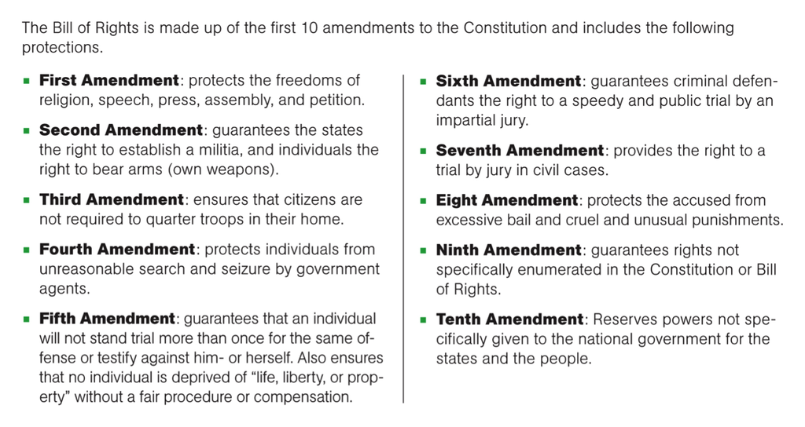

## The Bill of Rights

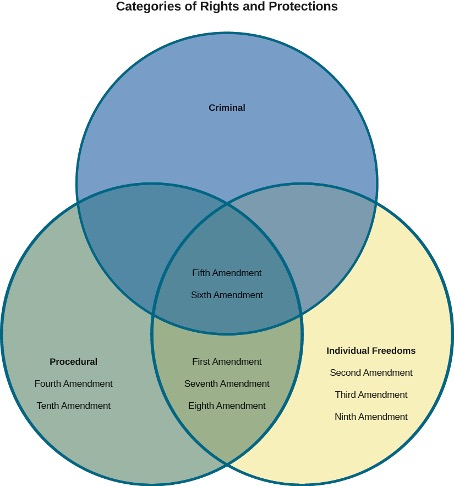

## The First Amendment

> *Congress shall make no law respecting an establishment of religion, or prohibiting the free exercise thereof; or abridging the freedom of speech, or of the press; or the right of the people peaceably to assemble, and to petition the Government for a redress of grievances*.

## The Establishment Clause and Free Exercise Clause

*I contemplate with sovereign reverence that act of the whole American people which declared that their legislature should “make no law respecting an establishment of religion, or prohibiting the free exercise thereof,” thus **building a wall of separation between Church & State***

Thomas Jefferson (1802), Letter to the Danbury Baptist association in the state of Connecticut

## Freedom of Expression

### Free speech, press, assembly, and petition

- **Freedom of expression** refers to the rights protected under the First Amendment’s Free Speech, Free Press, Free Assembly, and Right to Petition Clauses
  - Speech, press, and assembly rights often overlap

## Free Speech

- **Free Speech Clause**: prohibits the government from suppressing or restricting most forms of speech and symbolic speech (e.g., wearing certain attire, protesting, flag burning, and other forms of non-communicative speech)
  - Includes types of offensive speech, such as hate speech
  - Includes political speech, such as campaign donations by individuals and corporations
  - **Excludes** *incitement*, *true threats*, *fighting words*, *obscenity*, *defamation*

## Free Press, Assembly, Petition

- **Free Press Clause**: prohibits the government from restricting the right of the press to disseminate news and express opinions
- **Free Assembly Clause**: prohibits the government from restricting peaceable assemblies
- **Right to Petition Clause**: permits individuals or groups to petition the government, including writing and calling elected representatives, lobbying government officials, and filing lawsuits with the courts

[figure not shown]

## The Second Amendment

> *A well regulated Militia, being necessary to the security of a free State, the right of the people to keep and bear Arms, shall not be infringed*.
- *well regulated militia* or *right of the people*?

## Gun Control

- After the Civil War, many states introduced laws to prevent former slaves from possessing or carrying firearms
- In the 1930s, governments introduced laws restricting ownership and sale of certain types of firearms

## Gun Rights

### Do *individuals* have a right to possess fire arms?

- **Yes**. As of when?
- *District of Columbia v. Heller* (2008)
  - an **individual** right to bear arms *for traditionally lawful purposes, such as self-defense within the home*
  - Unconnected to service in an organized militia
- *McDonald v. Chicago* (2010)
  - incorporated the individual right to bear arms into the Due Process Clause of the Fourteenth Amendment

## The Third Amendment

> *The Third Amendment prevents the federal government from quartering soldiers in the home of any person without consent during peace time or, during wartime, in a manner not authorized by law*
- *Quartering Acts*: required American colonists to house British troops in their homes

## The Fourth Amendment

> *The right of the people to be secure in their persons, houses, papers, and effects, against unreasonable searches and seizures, shall not be violated, and no Warrants shall issue, but upon probable cause, supported by Oath or affirmation, and particularly describing the place to be searched, and the persons or things to be seized*

## The Fourth Amendment

- *secure in their persons*
- *unreasonable searches and seizures*
- Search warrant
- Probable cause

## The Fifth Amendment

> *No person shall be held to answer for a capital, or otherwise infamous crime, unless on a presentment or indictment of a Grand Jury, except in cases arising in the land or naval forces, or in the Militia, when in actual service in time of War or public danger; nor shall any person be subject for the same offence to be twice put in jeopardy of life or limb; nor shall be compelled in any criminal case to be a witness against himself, nor be deprived of life, liberty, or property, without due process of law; nor shall private property be taken for public use, without just compensation*

## The Fifth Amendment

- Indictment by a Grand Jury
- Double jeopardy
- Self-incrimination
  - *Miranda v. Arizona* (1966)
- **Due Process**
- Eminent domain

## The Sixth Amendment

> *In all criminal prosecutions, the accused shall enjoy the right to a speedy and public trial, by an impartial jury of the State and district wherein the crime shall have been committed, which district shall have been previously ascertained by law, and to be informed of the nature and cause of the accusation; to be confronted with the witnesses against him; to have compulsory process for obtaining witnesses in his favor, and to have the Assistance of Counsel for his defence*

## The Sixth Amendment

- a speedy trial
- a public trial
- an impartial jury
- a jury from the state where the alleged offense occurred
- the right to receive notice of accusations
- the right to confront witnesses
- the right to compel witnesses to testify
- the right to the assistance of counsel
  - public defenders
  - *Gideon v. Wainwright* (1963): guaranteed appointed counsel to defendants who cannot afford an attorney

## The Seventh and Eighth Amendment

- The Seventh Amendment addresses the rights of individuals engaged in civil (non-criminal) litigation
- The Eighth Amendment: *Excessive bail shall not be required, nor excessive fines imposed, nor cruel and unusual punishments inflicted*

## The Ninth Amendment

> *The enumeration in the Constitution, of certain rights, shall not be construed to deny or disparage others retained by the people*
- Different interpretations of the Ninth Amendment:
  - Protect certain *natural* or *common-law rights* not enshrined in the Constitution
    - *Right to privacy*
  - *It is a common error, but an error nonetheless, to talk of ‘ninth amendment rights.’ The ninth amendment is not a source of rights as such; it is simply a rule about how to read the Constitution* - Laurence Tribe

## The Tenth Amendment

> *The powers not delegated to the United States by the Constitution, nor prohibited by it to the States, are reserved to the States respectively, or to the people*
- The federal government has both enumerated and implied powers, but where the federal government does not (or chooses not to) exercise power, the states may do so

# Selective Incorporation

## The Bill of Rights and the States

- *Barron v. Baltimore* (1833)
  - The Bill of Rights applies only to the federal government
- Fourteenth Amendment
  - **Selective incorporation**: the gradual process of making some guarantees of the Bill of Rights apply to state governments
  - **Due process clause**: *nor shall any State deprive any person of life, liberty, or property, without **due process of law***

## Selective Incorporation History

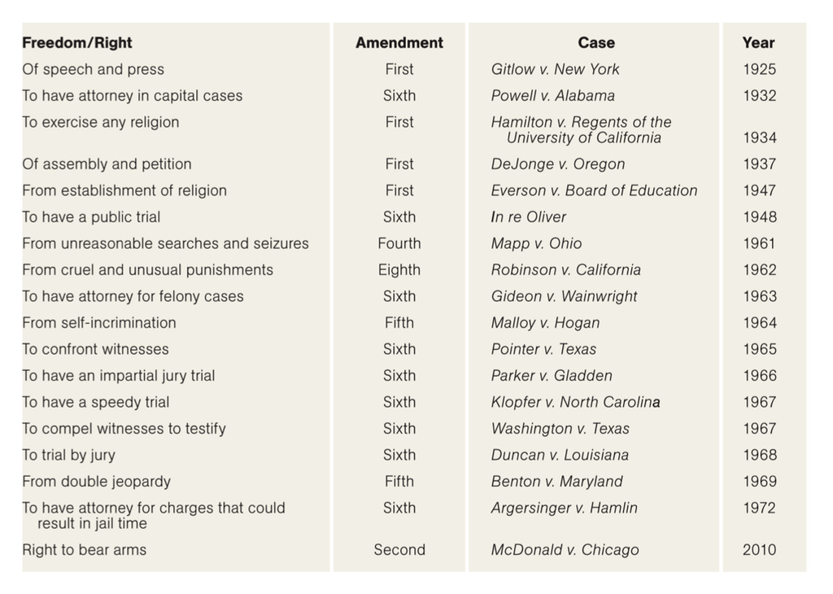